# splitGraph: From Metadata to Leakage-Aware Split Design

Selçuk Korkmaz

2026-11-24

## Why `splitGraph` exists

Leakage in biomedical evaluation workflows often comes from dataset structure rather than from an obvious coding mistake. Two samples may look independent in a model matrix while still sharing the same subject, batch, study, timepoint, or feature provenance. If those relationships stay implicit, train/test separation can look correct while violating the scientific separation you actually intended.

`splitGraph` exists to make those relationships explicit before evaluation. It turns metadata into a typed dependency graph that can be:

- validated for structural and leakage-relevant problems
- queried to inspect hidden overlap and provenance
- converted into deterministic split constraints
- translated into a stable, tool-agnostic split specification through the `split_spec` class and `as_split_spec()` / `validate_split_spec()` API
- serialized to a schema-versioned JSON that any language can consume (an R session, or the shipped Python reader driving scikit-learn)

The package is intentionally narrow. It does not fit models, run preprocessing pipelines, or generate resamples by itself. Its job is to represent dependency structure clearly enough that downstream evaluation can be trustworthy.

## A realistic toy dataset

The example below includes exactly the kinds of relationships that usually matter for leakage-aware evaluation:

- repeated subjects (`P1` and `P2`)
- reused batch (`B1`)
- one subject (`P2`) appearing across studies
- explicit time ordering with one sample missing time metadata
- a feature set derived at the full-dataset scope

```r
meta <- data.frame(
  sample_id = c("S1", "S2", "S3", "S4", "S5", "S6"),
  subject_id = c("P1", "P1", "P2", "P3", "P4", "P2"),
  batch_id = c("B1", "B2", "B1", "B3", NA, "B1"),
  study_id = c("ST1", "ST1", "ST1", "ST2", "ST3", "ST2"),
  timepoint_id = c("T0", "T1", "T0", "T2", NA, "T1"),
  assay_id = c("RNAseq", "RNAseq", "RNAseq", "RNAseq", "Proteomics", "RNAseq"),
  featureset_id = c("FS_GLOBAL", "FS_GLOBAL", "FS_GLOBAL", "FS_GLOBAL", "FS_PROT", "FS_GLOBAL"),
  outcome_id = c("O_case", "O_case", "O_ctrl", "O_case", "O_ctrl", "O_ctrl"),
  stringsAsFactors = FALSE
)

meta
```

```
#>   sample_id subject_id batch_id study_id timepoint_id   assay_id featureset_id
#> 1        S1         P1       B1      ST1           T0     RNAseq     FS_GLOBAL
#> 2        S2         P1       B2      ST1           T1     RNAseq     FS_GLOBAL
#> 3        S3         P2       B1      ST1           T0     RNAseq     FS_GLOBAL
#> 4        S4         P3       B3      ST2           T2     RNAseq     FS_GLOBAL
#> 5        S5         P4     <NA>      ST3         <NA> Proteomics       FS_PROT
#> 6        S6         P2       B1      ST2           T1     RNAseq     FS_GLOBAL
#>   outcome_id
#> 1     O_case
#> 2     O_case
#> 3     O_ctrl
#> 4     O_case
#> 5     O_ctrl
#> 6     O_ctrl
```

This is still a small example, but it already contains enough structure to make naive random splitting risky.

## Fast path: `graph_from_metadata()`

When your metadata already uses the canonical column names (`sample_id`, `subject_id`, `batch_id`, `study_id`, `timepoint_id`, `time_index`, `assay_id`, `featureset_id`, `site_id`, `region_id`, `platform_id`, `outcome_id` / `outcome_value`), `graph_from_metadata()` does ingestion, typed node construction, canonical edge construction, and optional `timepoint_precedes` derivation in a single call. Any canonical column that is absent is simply skipped, so you only supply the structure you have:

```r
quick_graph <- graph_from_metadata(
  data.frame(
    sample_id    = c("S1", "S2", "S3", "S4", "S5", "S6"),
    subject_id   = c("P1", "P1", "P2", "P2", "P3", "P3"),
    batch_id     = c("B1", "B2", "B1", "B2", "B1", "B2"),
    timepoint_id = c("T0", "T1", "T0", "T1", "T0", "T1"),
    time_index   = c(0, 1, 0, 1, 0, 1),
    outcome_id   = c("ctrl", "case", "ctrl", "case", "case", "ctrl")
  ),
  graph_name = "quick_demo"
)

quick_graph
```

```
#> <dependency_graph> quick_demo
#>   Nodes: 15
#>   Edges: 25
```

If you pass `outcome_value` as a numeric column (e.g. `0`/`1`), the package will create one `Outcome` node per distinct numeric value (`outcome:0`, `outcome:1`) and emit a warning. For most workflows you want a character class label, so prefer `outcome_id`.

The rest of this vignette uses the explicit constructor path because it lets us show node attributes (`time_index`, `visit_label`, `platform`, `derivation_scope`) and edges that `graph_from_metadata()` does not build for you on its own — specifically `featureset_generated_from_study` and `featureset_generated_from_batch`. (`subject_has_outcome` is the one non-default outcome edge `graph_from_metadata()` will build for you when you pass `outcome_scope = "subject"`.) Use `graph_from_metadata()` when the canonical columns are enough; use the explicit path when you need custom attributes or feature-provenance edges.

## Ingest metadata and build typed nodes and edges

The first step is to standardize metadata and then turn each entity type into canonical graph nodes. Sample-level relations become typed edges.

```r
meta <- ingest_metadata(meta, dataset_name = "VignetteDemo")

sample_nodes <- create_nodes(meta, type = "Sample", id_col = "sample_id")
subject_nodes <- create_nodes(meta, type = "Subject", id_col = "subject_id")
batch_nodes <- create_nodes(meta, type = "Batch", id_col = "batch_id")
study_nodes <- create_nodes(meta, type = "Study", id_col = "study_id")

time_nodes <- create_nodes(
  data.frame(
    timepoint_id = c("T0", "T1", "T2"),
    time_index = c(0L, 1L, 2L),
    visit_label = c("baseline", "follow_up", "late_follow_up"),
    stringsAsFactors = FALSE
  ),
  type = "Timepoint",
  id_col = "timepoint_id",
  attr_cols = c("time_index", "visit_label")
)

assay_nodes <- create_nodes(
  data.frame(
    assay_id = c("RNAseq", "Proteomics"),
    modality = c("transcriptomics", "proteomics"),
    platform = c("NovaSeq", "Orbitrap"),
    stringsAsFactors = FALSE
  ),
  type = "Assay",
  id_col = "assay_id",
  attr_cols = c("modality", "platform")
)

featureset_nodes <- create_nodes(
  data.frame(
    featureset_id = c("FS_GLOBAL", "FS_PROT"),
    featureset_name = c("global_rna_signature", "proteomics_panel"),
    derivation_scope = c("per_dataset", "external"),
    feature_count = c(500L, 80L),
    stringsAsFactors = FALSE
  ),
  type = "FeatureSet",
  id_col = "featureset_id",
  attr_cols = c("featureset_name", "derivation_scope", "feature_count")
)

outcome_nodes <- create_nodes(
  data.frame(
    outcome_id = c("O_case", "O_ctrl"),
    outcome_name = c("response", "response"),
    outcome_type = c("binary", "binary"),
    observation_level = c("subject", "subject"),
    stringsAsFactors = FALSE
  ),
  type = "Outcome",
  id_col = "outcome_id",
  attr_cols = c("outcome_name", "outcome_type", "observation_level")
)

subject_edges <- create_edges(
  meta, "sample_id", "subject_id",
  "Sample", "Subject", "sample_belongs_to_subject"
)

batch_edges <- create_edges(
  meta, "sample_id", "batch_id",
  "Sample", "Batch", "sample_processed_in_batch",
  allow_missing = TRUE
)

study_edges <- create_edges(
  meta, "sample_id", "study_id",
  "Sample", "Study", "sample_from_study"
)

time_edges <- create_edges(
  meta, "sample_id", "timepoint_id",
  "Sample", "Timepoint", "sample_collected_at_timepoint",
  allow_missing = TRUE
)

assay_edges <- create_edges(
  meta, "sample_id", "assay_id",
  "Sample", "Assay", "sample_measured_by_assay"
)

featureset_edges <- create_edges(
  meta, "sample_id", "featureset_id",
  "Sample", "FeatureSet", "sample_uses_featureset"
)

outcome_edges <- create_edges(
  data.frame(
    subject_id = c("P1", "P2", "P3", "P4"),
    outcome_id = c("O_case", "O_ctrl", "O_case", "O_ctrl"),
    stringsAsFactors = FALSE
  ),
  "subject_id", "outcome_id",
  "Subject", "Outcome", "subject_has_outcome"
)

precedence_edges <- create_edges(
  data.frame(
    from_timepoint = c("T0", "T1"),
    to_timepoint = c("T1", "T2"),
    stringsAsFactors = FALSE
  ),
  "from_timepoint", "to_timepoint",
  "Timepoint", "Timepoint", "timepoint_precedes"
)

featureset_from_study <- create_edges(
  data.frame(
    featureset_id = "FS_GLOBAL",
    study_id = "ST1",
    stringsAsFactors = FALSE
  ),
  "featureset_id", "study_id",
  "FeatureSet", "Study", "featureset_generated_from_study"
)

featureset_from_batch <- create_edges(
  data.frame(
    featureset_id = "FS_GLOBAL",
    batch_id = "B1",
    stringsAsFactors = FALSE
  ),
  "featureset_id", "batch_id",
  "FeatureSet", "Batch", "featureset_generated_from_batch"
)
```

The node and edge tables are canonical and typed. The package assigns globally unique node IDs such as `sample:S1` and `subject:P1`, so different entity types cannot collide accidentally.

```r
sample_nodes
```

```
#> <graph_node_set> 6 nodes across 1 types (schema 0.4.0 )
```

```r
as.data.frame(sample_nodes)[, c("node_id", "node_type", "node_key", "label")]
```

```
#>     node_id node_type node_key label
#> 1 sample:S1    Sample       S1    S1
#> 2 sample:S2    Sample       S2    S2
#> 3 sample:S3    Sample       S3    S3
#> 4 sample:S4    Sample       S4    S4
#> 5 sample:S5    Sample       S5    S5
#> 6 sample:S6    Sample       S6    S6
```

```r
edge_preview <- do.call(rbind, lapply(
  list(
    subject_edges, batch_edges, study_edges, time_edges,
    assay_edges, featureset_edges, outcome_edges,
    precedence_edges, featureset_from_study, featureset_from_batch
  ),
  as.data.frame
))

edge_preview[, c("from", "to", "edge_type")]
```

```
#>                    from                   to                       edge_type
#> 1             sample:S1           subject:P1       sample_belongs_to_subject
#> 2             sample:S2           subject:P1       sample_belongs_to_subject
#> 3             sample:S3           subject:P2       sample_belongs_to_subject
#> 4             sample:S4           subject:P3       sample_belongs_to_subject
#> 5             sample:S5           subject:P4       sample_belongs_to_subject
#> 6             sample:S6           subject:P2       sample_belongs_to_subject
#> 7             sample:S1             batch:B1       sample_processed_in_batch
#> 8             sample:S2             batch:B2       sample_processed_in_batch
#> 9             sample:S3             batch:B1       sample_processed_in_batch
#> 10            sample:S4             batch:B3       sample_processed_in_batch
#> 11            sample:S6             batch:B1       sample_processed_in_batch
#> 12            sample:S1            study:ST1               sample_from_study
#> 13            sample:S2            study:ST1               sample_from_study
#> 14            sample:S3            study:ST1               sample_from_study
```

[output cut: 28 more lines]

The node table shows the canonical sample IDs that everything else refers to. The edge table shows the package’s central design choice: dependency structure is explicit, typed, and inspectable.

## Assemble the dependency graph

```r
graph <- build_dependency_graph(
  nodes = list(
    sample_nodes, subject_nodes, batch_nodes, study_nodes,
    time_nodes, assay_nodes, featureset_nodes, outcome_nodes
  ),
  edges = list(
    subject_edges, batch_edges, study_edges, time_edges,
    assay_edges, featureset_edges, outcome_edges,
    precedence_edges, featureset_from_study, featureset_from_batch
  ),
  graph_name = "vignette_graph",
  dataset_name = attr(meta, "dataset_name")
)

graph
```

```
#> <dependency_graph> vignette_graph
#>   Nodes: 25
#>   Edges: 42
```

```r
summary(graph)
```

```
#> $graph_name
#> [1] "vignette_graph"
#>
#> $dataset_name
#> [1] "VignetteDemo"
#>
#> $schema_version
#> [1] "0.4.0"
#>
#> $n_nodes
#> [1] 25
#>
#> $n_edges
#> [1] 42
#>
#> $node_types
#>        value n
#> 1     Sample 6
#> 2    Subject 4
#> 3      Batch 3
#> 4      Study 3
#> 5  Timepoint 3
#> 6      Assay 2
#> 7 FeatureSet 2
#> 8    Outcome 2
#>
#> $edge_types
#>                              value n
#> 1        sample_belongs_to_subject 6
#> 2                sample_from_study 6
#> 3         sample_measured_by_assay 6
#> 4           sample_uses_featureset 6
#> 5    sample_collected_at_timepoint 5
#> 6        sample_processed_in_batch 5
#> 7              subject_has_outcome 4
#> 8               timepoint_precedes 2
#> 9  featureset_generated_from_batch 1
#> 10 featureset_generated_from_study 1
```

At this point the package has a single `dependency_graph` object with both tabular and `igraph` representations behind it. The summary is useful because it tells you exactly which entity types and relation types are present before you derive any split rules.

Both representations stay reachable. `graph$nodes` and `graph$edges` are the tables; `as_igraph()` hands you the `igraph` object, with `node_type` and `node_key` on the vertices and `edge_type` on the edges, so anything igraph can compute is available without leaving the typed model:

```r
ig <- as_igraph(graph)
ig
```

```
#> IGRAPH aa842d5 DN-- 25 42 --
#> + attr: name (v/c), node_type (v/c), node_key (v/c), label (v/c),
#> | edge_id (e/c), edge_type (e/c)
#> + edges from aa842d5 (vertex names):
#>  [1] sample:S1->subject:P1   sample:S2->subject:P1   sample:S3->subject:P2
#>  [4] sample:S4->subject:P3   sample:S5->subject:P4   sample:S6->subject:P2
#>  [7] sample:S1->batch:B1     sample:S2->batch:B2     sample:S3->batch:B1
#> [10] sample:S4->batch:B3     sample:S6->batch:B1     sample:S1->study:ST1
#> [13] sample:S2->study:ST1    sample:S3->study:ST1    sample:S4->study:ST2
#> [16] sample:S5->study:ST3    sample:S6->study:ST2    sample:S1->timepoint:T0
#> [19] sample:S2->timepoint:T1 sample:S3->timepoint:T0 sample:S4->timepoint:T2
#> + ... omitted several edges
```

```r
igraph::vertex_attr_names(ig)
```

```
#> [1] "name"      "node_type" "node_key"  "label"
```

### Visualize the typed structure

`plot()` renders the graph with a typed, layered layout: `Sample` on top, peer dependencies (`Subject`, `Batch`, `Study`, `Timepoint`) in the middle band, `Assay`/`FeatureSet` below that, and `Outcome` at the bottom. Node colors are keyed to type and an auto-generated legend is drawn by default.

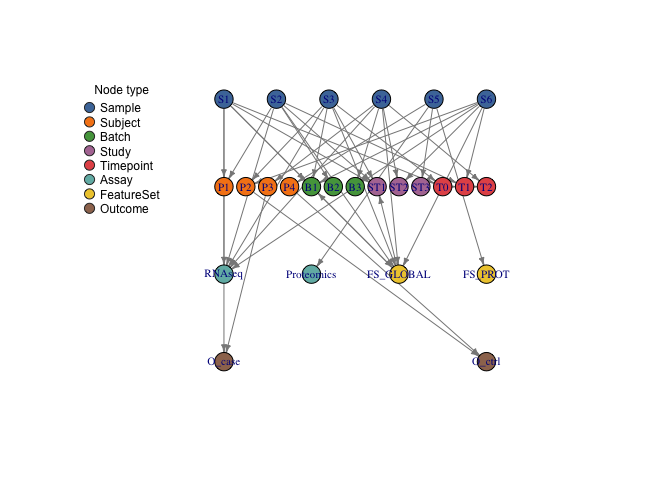

```r
plot(graph)
```

Useful options:

```r
plot(graph, layout = "sugiyama")         # alternative hierarchical layout
plot(graph, show_labels = FALSE)         # hide labels on dense graphs
plot(graph, legend = FALSE)              # suppress the legend
plot(graph, legend_position = "bottomright")
plot(graph, node_colors = c(Sample = "#000000"))
```

Two other views answer different questions. `focus = "sample_projection"` drops the dependency nodes and draws only the samples, joined whenever they share a dependency of a type in `via`: this is a picture of the grouping a composite derivation would produce, and a connected blob is a warning that the split has little room left. `focus = "ego"` zooms to one node’s neighbourhood, which is how you inspect a single subject or batch in a graph too large to read whole.

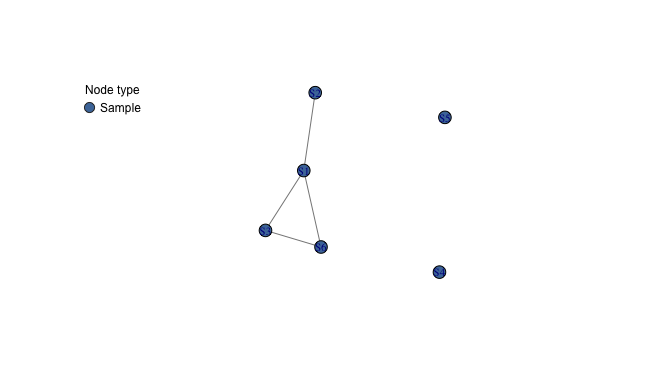

```r
plot(graph, focus = "sample_projection", via = c("Subject", "Batch"))
```

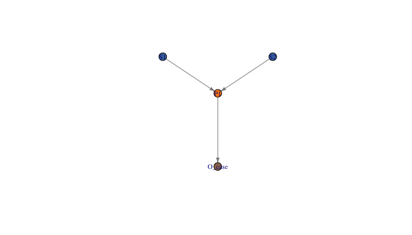

```r
plot(graph, focus = "ego", node = "subject:P1", legend = FALSE)
```

### Reshaping a graph you already have

You do not have to go back to the node and edge sets to change a graph. `subset_graph()` restricts it to a set of samples and keeps the structure those samples actually reach; `combine_graphs()` takes the union of several graphs, rejecting contradictory definitions of the same node; and `add_edges()` appends an edge set, for example one produced later from a kinship table. Each returns a new, independently validated graph and leaves its inputs untouched.

```r
train_graph <- subset_graph(graph, samples = c("S1", "S2", "S3", "S4"))
summary(train_graph)$node_types
```

```
#>        value n
#> 1     Sample 4
#> 2      Batch 3
#> 3    Subject 3
#> 4  Timepoint 3
#> 5    Outcome 2
#> 6      Study 2
#> 7      Assay 1
#> 8 FeatureSet 1
```

```r
# Grouping on the subset graph agrees with asking for a subset directly.
identical(
  grouping_vector(derive_split_constraints(train_graph, mode = "subject")),
  grouping_vector(derive_split_constraints(graph, mode = "subject",
                                           samples = c("S1", "S2", "S3", "S4")))
)
```

```
#> [1] TRUE
```

`combine_graphs()` is the inverse operation, and the natural way to assemble a cohort that arrived in pieces — one graph per batch of metadata, merged once they are all in:

```r
rejoined <- combine_graphs(
  subset_graph(graph, samples = c("S1", "S2", "S3")),
  subset_graph(graph, samples = c("S4", "S5", "S6")),
  graph_name = "rejoined"
)

identical(summary(rejoined)$node_types, summary(graph)$node_types)
```

```
#> [1] TRUE
```

```r
identical(
  grouping_vector(derive_split_constraints(rejoined, mode = "subject")),
  grouping_vector(derive_split_constraints(graph, mode = "subject"))
)
```

```
#> [1] TRUE
```

`add_edges()` covers the case where a relation only becomes available later. Kinship, for instance, arrives as its own matrix rather than as a metadata column; once you have it, thresholding it produces an edge set you can attach to the graph you already built, and `mode = "relatedness"` becomes available on it:

```r
kinship_table <- data.frame(
  id1     = c("P1", "P2"),
  id2     = c("P2", "P3"),
  kinship = c(0.25, 0.20),
  stringsAsFactors = FALSE
)

graph_with_kinship <- add_edges(
  graph,
  relatedness_edges_from_kinship(kinship_table, threshold = 0.1)
)

summary(graph_with_kinship)$edge_types
```

```
#>                              value n
#> 1        sample_belongs_to_subject 6
#> 2                sample_from_study 6
#> 3         sample_measured_by_assay 6
#> 4           sample_uses_featureset 6
#> 5    sample_collected_at_timepoint 5
#> 6        sample_processed_in_batch 5
#> 7              subject_has_outcome 4
#> 8               subject_related_to 2
#> 9               timepoint_precedes 2
#> 10 featureset_generated_from_batch 1
#> 11 featureset_generated_from_study 1
```

```r
grouping_vector(derive_split_constraints(graph_with_kinship, mode = "relatedness"))
```

```
#>                        S1                        S2                        S3
#> "relatedness:component_1" "relatedness:component_1" "relatedness:component_1"
#>                        S4                        S5                        S6
#> "relatedness:component_1" "relatedness:component_2" "relatedness:component_1"
```

`P1`, `P2` and `P3` form one relatedness component, so the five samples carried by those three subjects can no longer be separated; `P4`’s single sample stays on its own. The thresholded relations are covered in full further down and in the *modeling-structure* vignette.

### Exporting for other tools

JSON is the interchange contract, but for a look at the graph in Cytoscape, Gephi, or networkx, `export_graph()` writes GraphML, GML, or flat node and edge tables. Attributes are flattened into `attr_*` columns, since those formats cannot hold a nested list.

```r
export_graph(graph, "graph.graphml", format = "graphml")
export_graph(graph, "nodes.csv", format = "nodes_csv")
```

## Validate before you split

Validation is where `splitGraph` starts paying off. The graph below is structurally valid, but it still carries leakage-relevant warnings and advisories.

```r
validation <- validate_graph(graph)

validation
```

```
#> <depgraph_validation_report>  vignette_graph
#>   Valid: TRUE
#>   Issues: 8
#>   By severity:
#>    - advisory : 5
#>    - warning : 3
```

```r
as.data.frame(validation)[, c("level", "severity", "code", "message")]
```

```
#>     level severity                                 code
#> 1 leakage advisory             repeated_subject_samples
#> 2 leakage advisory             repeated_subject_samples
#> 3 leakage  warning          subject_cross_study_overlap
#> 4 leakage advisory               per_dataset_featureset
#> 5 leakage advisory         shared_featureset_provenance
#> 6 leakage advisory                    heavy_batch_reuse
#> 7 leakage  warning cross_study_featureset_contamination
#> 8 leakage  warning cross_batch_featureset_contamination
#>                                                                                                                                                                                                                                                                                                          …
#> 1                                                                                                                                                                                                                                                                         Subject `subject:P1` is linked …
#> 2                                                                                                                                                                                                                                                                         Subject `subject:P2` is linked …
#> 3                                                                                                                                                                                                                                                                       Subject `subject:P2` appears acro…
#> 4                                                                                                                                                                                                                                                    FeatureSet `featureset:FS_GLOBAL` was derived at the…
#> 5                                                                                                                                                                                                                                                        FeatureSet `featureset:FS_GLOBAL` is shared acro…
#> 6                                                                                                                                                                                                                                                                             Batch `batch:B1` is reused …
#> 7 FeatureSet `featureset:FS_GLOBAL` generated from study:ST1 is used by sample(s) outside its source study (sample:S4, sample:S6) while the source study's own samples are also in the data (3 sample(s)); if the FeatureSet was derived using those samples, evaluating them is not independent of how f…
#> 8  FeatureSet `featureset:FS_GLOBAL` generated from batch:B1 is used by sample(s) outside its source batch (sample:S2, sample:S4) while the source batch's own samples are also in the data (3 sample(s)); if the FeatureSet was derived using those samples, evaluating them is not independent of how f…
```

That output is the core value proposition of the package in one place:

- repeated subjects are surfaced explicitly
- cross-study subject overlap is surfaced explicitly
- full-dataset feature provenance is surfaced explicitly
- heavy batch reuse is surfaced explicitly

`valid = TRUE` here means the graph has no errors. It does not mean the dataset is free of leakage risk. Warnings and advisories still matter.

The report is a `depgraph_validation_report`: `print()` gives the severity roll-up above and `as.data.frame()` the issue table, with one row per finding and the node and edge ids it implicates.

| `code` | Default severity | Fires when |
| --- | --- | --- |
| `repeated_subject_samples` | advisory | a subject has more than one sample |
| `subject_cross_study_overlap` | warning | one subject’s samples span several studies |
| `subject_cross_site_overlap` | warning | one subject’s samples span several sites |
| `per_dataset_featureset` | advisory | a `FeatureSet` node declares `derivation_scope = "per_dataset"` |
| `shared_featureset_provenance` | advisory | one feature set is used by more than one sample |
| `missing_time_ordering` | warning | timepoint-linked samples exist with neither `time_index` nor `timepoint_precedes` |
| `heavy_batch_reuse` | advisory | one batch holds at least half the cohort (minimum 3 samples) |

None of these are errors, because none of them is wrong on its own — a longitudinal study is *supposed* to repeat subjects. They are the inputs to the split decision, which is why the report describes and does not prescribe.

Pass `levels = "leakage"` to run only that layer, and `severities =` to narrow the returned table further:

```r
as.data.frame(
  validate_graph(graph, levels = "leakage", severities = "warning")
)[, c("severity", "code", "message")]
```

```
#>   severity                                 code
#> 1  warning          subject_cross_study_overlap
#> 2  warning cross_study_featureset_contamination
#> 3  warning cross_batch_featureset_contamination
#>                                                                                                                                                                                                                                                                                                          …
#> 1                                                                                                                                                                                                                                                                       Subject `subject:P2` appears acro…
#> 2 FeatureSet `featureset:FS_GLOBAL` generated from study:ST1 is used by sample(s) outside its source study (sample:S4, sample:S6) while the source study's own samples are also in the data (3 sample(s)); if the FeatureSet was derived using those samples, evaluating them is not independent of how f…
#> 3  FeatureSet `featureset:FS_GLOBAL` generated from batch:B1 is used by sample(s) outside its source batch (sample:S2, sample:S4) while the source batch's own samples are also in the data (3 sample(s)); if the FeatureSet was derived using those samples, evaluating them is not independent of how f…
```

The package is also intentionally strict about silent failure. If you ask for a subset of samples and some of them do not resolve, it errors instead of dropping them.

```r
tryCatch(
  derive_split_constraints(graph, mode = "subject", samples = c("S1", "BAD")),
  error = function(e) e$message
)
```

```
#> [1] "Unknown sample IDs: BAD"
```

That behavior is important in practice because quietly omitting samples would change the truth of the split problem.

### When you really do need to relax a check

Some leakage-relevant rules have legitimate exceptions. For example, in some pooled designs a single biological “sample” is intentionally paired across two subjects. The semantic validator flags this as an error by default, and `derive_split_constraints(mode = "subject")` refuses to choose a subject for you — both consistent with the “no silent guessing” stance.

To make the contrast concrete, build a tiny graph in which sample `S1` is linked to two subjects:

```r
multi_nodes <- graph_node_set(data.frame(
  node_id   = c("sample:S1", "subject:P1", "subject:P2"),
  node_type = c("Sample", "Subject", "Subject"),
  node_key  = c("S1", "P1", "P2"),
  label     = c("S1", "P1", "P2"),
  attrs     = I(list(list(), list(), list())),
  stringsAsFactors = FALSE
))

multi_edges <- graph_edge_set(data.frame(
  edge_id   = c("sample_belongs_to_subject:1", "sample_belongs_to_subject:2"),
  from      = c("sample:S1", "sample:S1"),
  to        = c("subject:P1", "subject:P2"),
  edge_type = c("sample_belongs_to_subject", "sample_belongs_to_subject"),
  attrs     = I(list(list(), list())),
  stringsAsFactors = FALSE
))

multi_graph <- dependency_graph(nodes = multi_nodes, edges = multi_edges)
```

Default behavior — the validator surfaces the multi-subject sample as an error, and constraint derivation refuses to pick a subject:

```r
default_report <- validate_graph(multi_graph)
default_report$valid
```

```
#> [1] FALSE
```

```r
default_report$issues[, c("severity", "code", "message")]
```

```
#>   severity                                code
#> 1    error sample_multiple_subject_assignments
#>                                                                           message
#> 1 Samples violate relation cardinality for `sample_belongs_to_subject`: sample:S1
```

```r
tryCatch(
  derive_split_constraints(multi_graph, mode = "subject"),
  error = function(e) e$message
)
```

```
#> [1] "Multiple subject assignments found for sample(s): S1 (set `validation_overrides = list(allow_multi_subject_samples = TRUE)` to allow this and pick the first listed assignment.)"
```

When the ambiguity is intended, opt in explicitly via `validation_overrides`. The same key (`allow_multi_subject_samples = TRUE`) is honored by both the validator and the constraint deriver:

```r
# Validator: pass.
permissive_report <- validate_graph(
  multi_graph,
  validation_overrides = list(allow_multi_subject_samples = TRUE)
)
permissive_report$valid
```

```
#> [1] TRUE
```

```r
# Constraint derivation: pick the first listed subject and record the
# ambiguity in metadata$warnings instead of erroring.
multi_graph$metadata$validation_overrides <-
  list(allow_multi_subject_samples = TRUE)
relaxed_constraint <- derive_split_constraints(multi_graph, mode = "subject")
relaxed_constraint$sample_map[, c("sample_id", "group_id")]
```

```
#>   sample_id   group_id
#> 1        S1 subject:P1
```

```r
relaxed_constraint$metadata$warnings
```

```
#> [1] "Samples linked to multiple subjects were assigned to their first listed subject (allow_multi_subject_samples override): S1"
```

The override is documented under `?validate_graph`. Use it sparingly and only when the relaxation matches your scientific intent — the message in `metadata$warnings` is the audit trail that the choice was tolerated, not hidden.

## Query the graph to inspect hidden structure

Seven query functions read the graph without changing it. They all return a `graph_query_result`, so `as.data.frame()` gives you a tidy table in every case. Five of them work on the typed graph itself:

| Function | Answers |
| --- | --- |
| `query_node_type()` | which nodes of a given type exist |
| `query_edge_type()` | which edges of a given relation exist, optionally around given nodes |
| `query_neighbors()` | what a node is directly attached to |
| `query_paths()` | *every* simple route between two nodes |
| `query_shortest_paths()` | the shortest such route |

and two project the graph down to samples — `detect_shared_dependencies()` and `detect_dependency_components()` — which is what the splitting question actually asks.

Start with the inventory queries. They are the fastest way to check that the graph contains what you think it contains:

```r
as.data.frame(query_node_type(graph, "Batch"))[, c("node_id", "node_type", "node_key")]
```

```
#>     node_id node_type node_key
#> 11 batch:B1     Batch       B1
#> 12 batch:B2     Batch       B2
#> 13 batch:B3     Batch       B3
```

```r
# Which samples went through batch B1?
as.data.frame(
  query_edge_type(graph, "sample_processed_in_batch", node_ids = "batch:B1")
)[, c("edge_id", "from", "to")]
```

```
#>                        edge_id      from       to
#> 7  sample_processed_in_batch:1 sample:S1 batch:B1
#> 9  sample_processed_in_batch:3 sample:S3 batch:B1
#> 11 sample_processed_in_batch:5 sample:S6 batch:B1
```

Then inspect local provenance and trace paths.

```r
neighbors_s1 <- query_neighbors(graph, node_ids = "sample:S1", direction = "out")
neighbors_s1
```

```
#> <graph_query_result> query_neighbors
#>   Rows: 6
```

```r
as.data.frame(neighbors_s1)[, c("seed_node_id", "node_id", "node_type", "edge_type")]
```

```
#>   seed_node_id              node_id  node_type                     edge_type
#> 1    sample:S1           subject:P1    Subject     sample_belongs_to_subject
#> 2    sample:S1             batch:B1      Batch     sample_processed_in_batch
#> 3    sample:S1            study:ST1      Study             sample_from_study
#> 4    sample:S1         timepoint:T0  Timepoint sample_collected_at_timepoint
#> 5    sample:S1         assay:RNAseq      Assay      sample_measured_by_assay
#> 6    sample:S1 featureset:FS_GLOBAL FeatureSet        sample_uses_featureset
```

```r
subject_outcome_path <- query_shortest_paths(
  graph,
  from = "sample:S1",
  to = "outcome:O_case",
  edge_types = c("sample_belongs_to_subject", "subject_has_outcome")
)

subject_outcome_path
```

```
#> <graph_query_result> query_shortest_paths
#>   Rows: 3
```

```r
as.data.frame(subject_outcome_path)
```

```
#>   path_id step        node_id node_type                     edge_id
#> 1  path_1    1      sample:S1    Sample                        <NA>
#> 2  path_1    2     subject:P1   Subject sample_belongs_to_subject:1
#> 3  path_1    3 outcome:O_case   Outcome       subject_has_outcome:1
#>                   edge_type
#> 1                      <NA>
#> 2 sample_belongs_to_subject
#> 3       subject_has_outcome
```

The first query shows everything the graph knows directly about `S1`. The second shows that `S1` reaches the subject-level outcome through its subject node, which is exactly the kind of relationship that would stay implicit in a plain metadata table.

`query_shortest_paths()` returns one route. When the question is *how many different ways* two samples are entangled, use `query_paths()`, which enumerates every simple path. Setting `mode = "all"` ignores edge direction — dependency edges point from the sample outwards, so any sample-to-sample route has to traverse one of them backwards — and `max_length = 2` restricts the answer to dependencies shared one hop away:

```r
s1_to_s6 <- query_paths(graph, from = "sample:S1", to = "sample:S6",
                        mode = "all", max_length = 2)
s1_to_s6
```

```
#> <graph_query_result> query_paths
#>   Rows: 9
```

```r
as.data.frame(s1_to_s6)[, c("path_id", "step", "node_id", "node_type")]
```

```
#>   path_id step              node_id  node_type
#> 1  path_1    1            sample:S1     Sample
#> 2  path_1    2             batch:B1      Batch
#> 3  path_1    3            sample:S6     Sample
#> 4  path_2    1            sample:S1     Sample
#> 5  path_2    2         assay:RNAseq      Assay
#> 6  path_2    3            sample:S6     Sample
#> 7  path_3    1            sample:S1     Sample
#> 8  path_3    2 featureset:FS_GLOBAL FeatureSet
#> 9  path_3    3            sample:S6     Sample
```

Three separate routes connect `S1` and `S6`: the batch, the assay, and the feature set. A single shared column would have shown you one of them. `max_length` defaults to a finite cap of 8 edges so that a dense graph cannot make the enumeration explode; when a returned path sits at the cap, the result records `metadata$truncated = TRUE` to say longer routes may have been suppressed. Pass `max_length = Inf` to search exhaustively.

```r
shared_dependencies <- detect_shared_dependencies(
  graph,
  via = c("Subject", "Batch", "FeatureSet")
)

as.data.frame(shared_dependencies)[, c(
  "sample_id_1", "sample_id_2", "shared_node_type", "shared_node_id", "edge_type"
)]
```

```
#>    sample_id_1 sample_id_2 shared_node_type       shared_node_id
#> 1           S1          S2          Subject           subject:P1
#> 2           S3          S6          Subject           subject:P2
#> 3           S1          S3            Batch             batch:B1
#> 4           S1          S6            Batch             batch:B1
#> 5           S3          S6            Batch             batch:B1
#> 6           S1          S2       FeatureSet featureset:FS_GLOBAL
#> 7           S1          S3       FeatureSet featureset:FS_GLOBAL
#> 8           S1          S4       FeatureSet featureset:FS_GLOBAL
#> 9           S1          S6       FeatureSet featureset:FS_GLOBAL
#> 10          S2          S3       FeatureSet featureset:FS_GLOBAL
#> 11          S2          S4       FeatureSet featureset:FS_GLOBAL
#> 12          S2          S6       FeatureSet featureset:FS_GLOBAL
#> 13          S3          S4       FeatureSet featureset:FS_GLOBAL
#> 14          S3          S6       FeatureSet featureset:FS_GLOBAL
```

[output cut: 17 more lines]

```r
dependency_components <- detect_dependency_components(
  graph,
  via = c("Subject", "Batch")
)

as.data.frame(dependency_components)
```

```
#>   sample_id sample_node_id component_id component_size
#> 1        S1      sample:S1  component_1              4
#> 2        S2      sample:S2  component_1              4
#> 3        S3      sample:S3  component_1              4
#> 4        S4      sample:S4  component_2              1
#> 5        S5      sample:S5  component_3              1
#> 6        S6      sample:S6  component_1              4
```

These projected queries are useful because they answer the splitting question directly. They tell you which samples should be treated as structurally linked, not just which metadata columns happen to match.

## Derive split constraints from the graph

`splitGraph` derives *direct* constraints — one grouping node per sample — for `subject`, `batch`, `study`, `time`, `site`, `region`, `platform`, and `assay`, plus *composite* constraints that combine several dependency sources, and *pairwise* constraints (`relatedness`, `spatial`) built from thresholded similarity. This section demonstrates the core four (`subject`, `batch`, `study`, `time`) and both composite strategies; the cluster relations (`site`, `region`, `platform`, `assay`) and the pairwise relations are covered in their own sections below and, in more depth, in the *modeling-structure* vignette.

```r
subject_constraint <- derive_split_constraints(graph, mode = "subject")
batch_constraint <- derive_split_constraints(graph, mode = "batch")
study_constraint <- derive_split_constraints(graph, mode = "study")
time_constraint <- derive_split_constraints(graph, mode = "time")

strict_constraint <- derive_split_constraints(
  graph,
  mode = "composite",
  strategy = "strict",
  via = c("Subject", "Batch")
)

rule_based_constraint <- derive_split_constraints(
  graph,
  mode = "composite",
  strategy = "rule_based",
  priority = c("batch", "study", "subject", "time")
)

constraint_overview <- do.call(rbind, lapply(
  list(
    subject = subject_constraint,
    batch = batch_constraint,
    study = study_constraint,
    time = time_constraint,
    composite_strict = strict_constraint,
    composite_rule = rule_based_constraint
  ),
  function(x) {
    data.frame(
      strategy = x$strategy,
      groups = length(unique(x$sample_map$group_id)),
      warnings = if (is.null(x$metadata$warnings)) 0L else length(x$metadata$warnings),
      stringsAsFactors = FALSE
    )
  }
))

constraint_overview <- cbind(constraint = row.names(constraint_overview), constraint_overview)
row.names(constraint_overview) <- NULL

constraint_overview
```

```
#>         constraint   strategy groups warnings
#> 1          subject    subject      4        0
#> 2            batch      batch      4        1
#> 3            study      study      3        0
#> 4             time       time      4        1
#> 5 composite_strict     strict      3        0
#> 6   composite_rule rule_based      4        0
```

That summary already shows why the package is useful: different notions of dependency produce different splitting units.

### Batch constraints

```r
batch_constraint
```

```
#> <split_constraint> batch
#>   Samples: 6
#>   Groups: 4
#>   Warnings: 1
```

```r
as.data.frame(batch_constraint)[, c("sample_id", "group_id", "group_label", "explanation")]
```

```
#>   sample_id          group_id group_label
#> 1        S1          batch:B1          B1
#> 2        S2          batch:B2          B2
#> 3        S3          batch:B1          B1
#> 4        S4          batch:B3          B3
#> 5        S5 batch:unlinked:S5 unlinked_S5
#> 6        S6          batch:B1          B1
#>                                                                          explanation
#> 1                          Grouped by batch through sample_processed_in_batch -> B1.
#> 2                          Grouped by batch through sample_processed_in_batch -> B2.
#> 3                          Grouped by batch through sample_processed_in_batch -> B1.
#> 4                          Grouped by batch through sample_processed_in_batch -> B3.
#> 5 No batch assignment was available; sample retained as an unlinked singleton group.
#> 6                          Grouped by batch through sample_processed_in_batch -> B1.
```

Batch grouping keeps all `B1` samples together and preserves `S5` as an explicit singleton because it has no batch assignment. Missing structure is not hidden.

### Time constraints

```r
time_constraint
```

```
#> <split_constraint> time
#>   Samples: 6
#>   Groups: 4
#>   Warnings: 1
```

```r
as.data.frame(time_constraint)[, c("sample_id", "group_id", "timepoint_id", "order_rank")]
```

```
#>   sample_id         group_id timepoint_id order_rank
#> 1        S1          time:T0           T0          1
#> 2        S2          time:T1           T1          2
#> 3        S3          time:T0           T0          1
#> 4        S4          time:T2           T2          3
#> 5        S5 time:unlinked:S5         <NA>         NA
#> 6        S6          time:T1           T1          2
```

Time grouping adds `order_rank`, which is the field downstream tooling actually needs for ordered evaluation. The missing timepoint on `S5` stays visible as `NA`, so ordering is partial rather than pretended.

### Composite constraints

```r
strict_constraint
```

```
#> <split_constraint> strict
#>   Samples: 6
#>   Groups: 3
```

```r
as.data.frame(strict_constraint)[, c("sample_id", "group_id", "constraint_type")]
```

```
#>   sample_id    group_id  constraint_type
#> 1        S1 component_1 composite_strict
#> 2        S2 component_1 composite_strict
#> 3        S3 component_1 composite_strict
#> 4        S4 component_2 composite_strict
#> 5        S5 component_3 composite_strict
#> 6        S6 component_1 composite_strict
```

```r
rule_based_constraint
```

```
#> <split_constraint> rule_based
#>   Samples: 6
#>   Groups: 4
```

```r
as.data.frame(rule_based_constraint)[, c("sample_id", "group_id", "constraint_type", "group_label")]
```

```
#>   sample_id            group_id constraint_type group_label
#> 1        S1  composite_batch:B1           batch          B1
#> 2        S2  composite_batch:B2           batch          B2
#> 3        S3  composite_batch:B1           batch          B1
#> 4        S4  composite_batch:B3           batch          B3
#> 5        S5 composite_study:ST3           study         ST3
#> 6        S6  composite_batch:B1           batch          B1
```

The strict composite constraint uses transitive closure: `S1`, `S2`, `S3`, and `S6` end up in the same group because subject and batch links connect them into one dependency component. The rule-based composite constraint is different: it uses the highest-priority available dependency per sample, so `S5` falls back to study-level grouping instead of becoming a composite component.

## Cluster-style relations: site, region, platform, assay

Beyond subject/batch/study/time, several other metadata columns define *cluster-style* leakage axes — categorical groupings a model can memorize instead of generalizing across. `splitGraph` models each as a first-class node type with its own auto-detected column, validation rule, and constraint mode:

| Relation | Column | Edge | Mode |
| --- | --- | --- | --- |
| Collection site / center | `site_id` | `sample_collected_at_site` | `"site"` |
| Tissue / anatomical region | `region_id` | `sample_located_in_region` | `"region"` |
| Sequencing / measurement platform | `platform_id` | `sample_run_on_platform` | `"platform"` |
| Assay / modality | `assay_id` | `sample_measured_by_assay` | `"assay"` |

They all behave identically: `graph_from_metadata()` auto-detects the column, `validate_graph()` flags samples assigned to more than one target, the mode groups samples so no cluster straddles a split, and `as_split_spec()` carries the assignment as a blocking annotation (`site_group`, `region_group`, `platform_group`, `assay_group`).

### Site

In multi-site studies, the collection site is a common leakage axis: a model can “recognize” a site rather than generalize across sites. `splitGraph` models the site as a first-class `Site` node connected by `sample_collected_at_site` edges. `graph_from_metadata()` auto-detects a `site_id` column, so no extra wiring is needed.

```r
site_meta <- data.frame(
  sample_id  = c("S1", "S2", "S3", "S4", "S5", "S6"),
  subject_id = c("P1", "P1", "P2", "P2", "P3", "P3"),
  site_id    = c("NYC", "NYC", "BOS", "BOS", "NYC", "BOS"),
  stringsAsFactors = FALSE
)

site_graph <- graph_from_metadata(site_meta, graph_name = "multi-site")

# Group samples so that no collection site straddles a train/test split.
site_constraint <- derive_split_constraints(site_graph, mode = "site")
as.data.frame(site_constraint)[, c("sample_id", "group_id", "group_label")]
```

```
#>   sample_id group_id group_label
#> 1        S1 site:NYC         NYC
#> 2        S2 site:NYC         NYC
#> 3        S3 site:BOS         BOS
#> 4        S4 site:BOS         BOS
#> 5        S5 site:NYC         NYC
#> 6        S6 site:BOS         BOS
```

`mode = "site"` keeps every sample from a given site in the same group. The site assignment is also carried into the `split_spec` as a blocking annotation (`site_group`), so a downstream consumer can block on site even when the primary grouping is something else (e.g. subject):

```r
subject_then_block_by_site <- as_split_spec(
  derive_split_constraints(site_graph, mode = "subject"),
  graph = site_graph
)
subject_then_block_by_site$block_vars
```

```
#> [1] "site_group"
```

```r
head(subject_then_block_by_site$sample_data[, c("sample_id", "group_id", "site_group")])
```

```
#>   sample_id   group_id site_group
#> 1        S1 subject:P1        NYC
#> 2        S2 subject:P1        NYC
#> 3        S3 subject:P2        BOS
#> 4        S4 subject:P2        BOS
#> 5        S5 subject:P3        NYC
#> 6        S6 subject:P3        BOS
```

Samples assigned to more than one site are rejected rather than silently resolved, by both `validate_graph()` and `derive_split_constraints(mode = "site")`.

Validation also watches the other direction. Subject `P3` above contributed `S5` at `NYC` and `S6` at `BOS`, so a site-grouped split would separate two samples from the same person — the mirror image of the cross-study overlap seen earlier, and the reason to read the validation report before committing to a mode:

```r
as.data.frame(validate_graph(site_graph))[
  , c("severity", "code", "message")
]
```

```
#>   severity                       code
#> 1 advisory   repeated_subject_samples
#> 2 advisory   repeated_subject_samples
#> 3 advisory   repeated_subject_samples
#> 4  warning subject_cross_site_overlap
#>                                                         message
#> 1           Subject `subject:P1` is linked to multiple samples.
#> 2           Subject `subject:P2` is linked to multiple samples.
#> 3           Subject `subject:P3` is linked to multiple samples.
#> 4 Subject `subject:P3` has samples collected at multiple sites.
```

### Region

The `Region` relation works the same way for a categorical tissue or anatomical region (`region_id` column, `sample_located_in_region` edge, `derive_split_constraints(mode = "region")`), so samples from the same region stay together across a split.

```r
region_meta <- data.frame(
  sample_id = c("S1", "S2", "S3", "S4"),
  region_id = c("cortex", "cortex", "hippocampus", "hippocampus"),
  stringsAsFactors = FALSE
)
region_graph <- graph_from_metadata(region_meta, graph_name = "regions")
as.data.frame(derive_split_constraints(region_graph, mode = "region"))[
  , c("sample_id", "group_id", "group_label")
]
```

```
#>   sample_id           group_id group_label
#> 1        S1      region:cortex      cortex
#> 2        S2      region:cortex      cortex
#> 3        S3 region:hippocampus hippocampus
#> 4        S4 region:hippocampus hippocampus
```

### Platform and assay

Technical measurement structure is the same story. `platform_id` (the sequencing instrument or measurement platform) and `assay_id` (the assay or modality) are both auto-detected, and `mode = "platform"` / `mode = "assay"` group samples so a whole platform or assay never straddles a split — useful when a batch effect tracks the instrument rather than the run.

```r
tech_meta <- data.frame(
  sample_id   = c("S1", "S2", "S3", "S4"),
  platform_id = c("illumina", "illumina", "nanopore", "nanopore"),
  assay_id    = c("rnaseq", "rnaseq", "wgs", "wgs"),
  stringsAsFactors = FALSE
)
tech_graph <- graph_from_metadata(tech_meta, graph_name = "tech")

as.data.frame(derive_split_constraints(tech_graph, mode = "platform"))[
  , c("sample_id", "group_id", "group_label")
]
```

```
#>   sample_id          group_id group_label
#> 1        S1 platform:illumina    illumina
#> 2        S2 platform:illumina    illumina
#> 3        S3 platform:nanopore    nanopore
#> 4        S4 platform:nanopore    nanopore
```

```r
as.data.frame(derive_split_constraints(tech_graph, mode = "assay"))[
  , c("sample_id", "group_id", "group_label")
]
```

```
#>   sample_id     group_id group_label
#> 1        S1 assay:rnaseq      rnaseq
#> 2        S2 assay:rnaseq      rnaseq
#> 3        S3    assay:wgs         wgs
#> 4        S4    assay:wgs         wgs
```

These new types are first-class in the typed layout too. Building a graph that carries several of them shows how each gets its own colour and layer band — the same visual vocabulary as the core types, so a mixed graph stays readable:

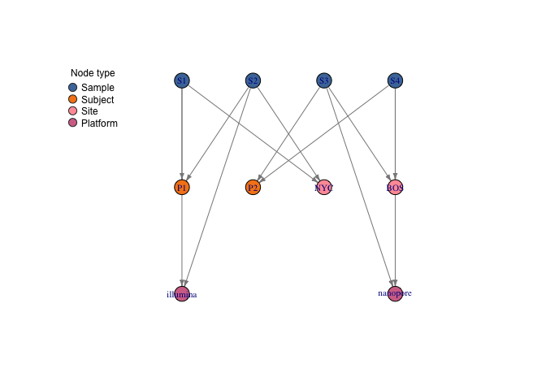

```r
mixed_meta <- data.frame(
  sample_id   = c("S1", "S2", "S3", "S4"),
  subject_id  = c("P1", "P1", "P2", "P2"),
  site_id     = c("NYC", "NYC", "BOS", "BOS"),
  platform_id = c("illumina", "illumina", "nanopore", "nanopore"),
  stringsAsFactors = FALSE
)
plot(graph_from_metadata(mixed_meta, graph_name = "mixed_structure"))
```

### Pairwise relations: relatedness and spatial proximity

Not every leakage source is a clean categorical group. Genetic relatedness and spatial proximity are *pairwise and continuous*: they link individual pairs by a similarity score. `splitGraph` models these as thresholded, undirected edges built with `relatedness_edges_from_kinship()` and `spatial_edges_from_coords()`, then `mode = "relatedness"` / `mode = "spatial"` form groups by transitive closure over the surviving edges — so a chain of individually near neighbours still lands in one group, a grouping a single column cannot express.

The example below keeps subject pairs whose kinship is at least `0.1`. `P1`–`P2` and `P2`–`P3` clear the threshold, so those three subjects collapse into one group by transitive closure; the unrelated `P4` stays on its own:

```r
kin <- data.frame(
  id1     = c("P1", "P2", "P1"),
  id2     = c("P2", "P3", "P4"),
  kinship = c(0.25, 0.20, 0.02),   # P1-P4 is below the 0.1 threshold
  stringsAsFactors = FALSE
)
rel_edges <- relatedness_edges_from_kinship(kin, threshold = 0.1)

rel_meta <- data.frame(
  sample_id  = paste0("S", 1:4),
  subject_id = c("P1", "P2", "P3", "P4"),
  stringsAsFactors = FALSE
)
rel_graph <- build_dependency_graph(
  nodes = list(
    create_nodes(rel_meta, "Sample", "sample_id"),
    create_nodes(rel_meta, "Subject", "subject_id")
  ),
  edges = list(
    create_edges(rel_meta, "sample_id", "subject_id",
                 "Sample", "Subject", "sample_belongs_to_subject"),
    rel_edges
  )
)

grouping_vector(derive_split_constraints(rel_graph, mode = "relatedness"))
```

```
#>                        S1                        S2                        S3
#> "relatedness:component_1" "relatedness:component_1" "relatedness:component_1"
#>                        S4
#> "relatedness:component_2"
```

The `spatial` mode works identically over sample coordinates (`spatial_edges_from_coords(coords, radius)`). Both relations — with the full scikit-learn handoff — are covered in depth in the *modeling-structure* vignette:

```r
vignette("modeling-structure", package = "splitGraph")
```

## Time ordering can come from precedence edges alone

If explicit `time_index` metadata are unavailable, `splitGraph` can still infer time order from `timepoint_precedes` edges.

```r
precedence_meta <- data.frame(
  sample_id = c("S1", "S2", "S3"),
  subject_id = c("P1", "P1", "P2"),
  study_id = c("ST1", "ST1", "ST2"),
  timepoint_id = c("T0", "T1", "T2"),
  stringsAsFactors = FALSE
)

precedence_graph <- build_dependency_graph(
  nodes = list(
    create_nodes(precedence_meta, type = "Sample", id_col = "sample_id"),
    create_nodes(precedence_meta, type = "Subject", id_col = "subject_id"),
    create_nodes(precedence_meta, type = "Study", id_col = "study_id"),
    create_nodes(
      data.frame(timepoint_id = c("T0", "T1", "T2"), stringsAsFactors = FALSE),
      type = "Timepoint",
      id_col = "timepoint_id"
    )
  ),
  edges = list(
    create_edges(
      precedence_meta, "sample_id", "subject_id",
      "Sample", "Subject", "sample_belongs_to_subject"
    ),
    create_edges(
      precedence_meta, "sample_id", "study_id",
      "Sample", "Study", "sample_from_study"
    ),
    create_edges(
      precedence_meta, "sample_id", "timepoint_id",
      "Sample", "Timepoint", "sample_collected_at_timepoint"
    ),
    create_edges(
      data.frame(
        from_timepoint = c("T0", "T1"),
        to_timepoint = c("T1", "T2"),
        stringsAsFactors = FALSE
      ),
      "from_timepoint", "to_timepoint",
      "Timepoint", "Timepoint", "timepoint_precedes"
    )
  ),
  graph_name = "precedence_only_graph"
)

precedence_time_constraint <- derive_split_constraints(precedence_graph, mode = "time")

precedence_time_constraint$metadata$time_order_source
```

```
#> [1] "timepoint_precedes"
```

```r
as.data.frame(precedence_time_constraint)[, c("sample_id", "timepoint_id", "time_index", "order_rank")]
```

```
#>   sample_id timepoint_id time_index order_rank
#> 1        S1           T0         NA          1
#> 2        S2           T1         NA          2
#> 3        S3           T2         NA          3
```

The important detail is that ordering is still derived, but the source is `timepoint_precedes` rather than `time_index`.

## Translate the constraint into a split specification

The graph-derived constraint is not the end of the workflow. The main handoff target is a canonical sample-level split specification — the `split_spec` class. Downstream tools consume it through their own adapters, so `split_spec` stays tool-agnostic.

```r
split_spec <- as_split_spec(strict_constraint, graph = graph)
split_spec
```

```
#> <split_spec> composite
#>   Samples: 6
#>   Groups: 3
#>   Block vars: batch_group, study_group, assay_group
#>   Time var: order_rank
#>   Stratum var: stratum
#>   Recommended resampling: custom_grouped_cv
```

```r
as.data.frame(split_spec)[, c(
  "sample_id", "group_id", "batch_group", "study_group",
  "stratum", "timepoint_id", "order_rank"
)]
```

```
#>   sample_id    group_id batch_group study_group stratum timepoint_id order_rank
#> 1        S1 component_1          B1         ST1  O_case           T0          1
#> 2        S2 component_1          B2         ST1  O_case           T1          2
#> 3        S3 component_1          B1         ST1  O_ctrl           T0          1
#> 4        S4 component_2          B3         ST2  O_case           T2          3
#> 5        S5 component_3        <NA>         ST3  O_ctrl         <NA>         NA
#> 6        S6 component_1          B1         ST2  O_ctrl           T1          2
```

```r
split_spec_validation <- validate_split_spec(split_spec)
split_spec_validation
```

```
#> <split_spec_validation>
#>   Valid: TRUE
#>   Issues: 0
```

```r
as.data.frame(split_spec_validation)
```

```
#> [1] issue_id   severity   code       message    n_affected details
#> <0 rows> (or 0-length row.names)
```

This translation step is where the package becomes operational for downstream evaluation workflows:

- `group_id` carries the split unit
- `batch_group` and `study_group` are available for blocking, alongside `site_group`, `region_group`, `platform_group` and `assay_group` when the graph carries those relations
- `order_rank` is available for ordered evaluation
- `stratum` carries the outcome level each sample has, so a consumer can stratify; it is an annotation only, and `splitGraph` never balances folds
- the generated object is validated before handoff

The declared roles are readable off the spec itself, which is what an adapter keys on rather than guessing column names:

```r
split_spec$group_var
```

```
#> [1] "group_id"
```

```r
split_spec$block_vars
```

```
#> [1] "batch_group" "study_group" "assay_group"
```

```r
split_spec$time_var
```

```
#> [1] "order_rank"
```

```r
split_spec$stratum_var
```

```
#> [1] "stratum"
```

## Summarize the leakage picture in one object

The final helper combines graph validation, constraint diagnostics, and split-spec readiness into one `leakage_risk_summary` object. Crucially, when you pass the `constraint` you chose, it reports a `severed` column: whether that constraint **structurally eliminates** each leakage path (`TRUE`), leaves it open (`FALSE`), or is not applicable (`NA`, e.g. for informational split-spec rows).

```r
risk_summary <- summarize_leakage_risks(
  graph,
  constraint = strict_constraint,
  split_spec = split_spec
)

risk_summary
```

```
#> <leakage_risk_summary>
#>   Overview: Detected 15 structural leakage diagnostics across validation, constraint, and split-spec readiness.
#>   Diagnostics: 15
```

```r
as.data.frame(risk_summary)[, c("source", "severity", "category", "severed", "message")]
```

```
#>        source severity                             category severed
#> 1  validation advisory             repeated_subject_samples    TRUE
#> 2  validation advisory             repeated_subject_samples    TRUE
#> 3  validation  warning          subject_cross_study_overlap    TRUE
#> 4  validation advisory               per_dataset_featureset   FALSE
#> 5  validation advisory         shared_featureset_provenance   FALSE
#> 6  validation advisory                    heavy_batch_reuse    TRUE
#> 7  validation  warning cross_study_featureset_contamination   FALSE
#> 8  validation  warning cross_batch_featureset_contamination   FALSE
#> 9  constraint advisory           singleton_heavy_constraint      NA
#> 10 split_spec advisory                     split_spec_ready      NA
#> 11 split_spec advisory                   ordering_available      NA
#> 12 split_spec advisory                   blocking_available      NA
#> 13 split_spec advisory                   blocking_available      NA
#> 14 split_spec advisory                   blocking_available      NA
```

[output cut: 17 more lines]

## Downstream handoff

`split_spec` is the tool-agnostic handoff artifact. `splitGraph` does not know about any particular resampling package — downstream consumers provide their own adapters so `splitGraph` stays neutral. The typical end-to-end flow is:

1. `graph_from_metadata()` (or the explicit constructor path) → typed `dependency_graph`
2. `derive_split_constraints(g, mode = ...)` → `split_constraint`
3. `as_split_spec(constraint, graph = g)` → `split_spec`
4. (optional) `write_split_spec(spec, path)` → JSON, for cross-session or cross-language handoff
5. adapter in the downstream package → native resamples

The `sample_data` frame carried by `split_spec` exposes exactly the columns downstream adapters consume: `sample_id` for joining against the observation frame, `group_id` for grouped resampling, `batch_group` / `study_group` for blocking, and `order_rank` for ordered evaluation. Adapters can be built by any package that wants to consume a `split_spec` — for example, on top of `rsample::group_vfold_cv()` (grouped CV keyed to `group_id`) or `rsample::rolling_origin()` (ordered evaluation keyed to `order_rank`).

### Persisting the handoff

If the downstream consumer is in a different R session — or in a different language entirely — write the spec (and, if useful, the graph) to JSON. The on-disk format has a formal JSON Schema (Draft 2020-12) shipped under `inst/schema/<schema_version>/`, and each written file references its own version via a `$schema` key, so the reference stays valid after later schema bumps. You can validate a handoff file against that contract with `validate_split_spec_json()` before consuming it, or ask the reader to do it by passing `validate = TRUE`, and `NA` values round-trip as JSON `null`.

```r
spec_path <- tempfile(fileext = ".json")
write_split_spec(split_spec, spec_path)

# Validate the file against the shipped JSON Schema.
validate_split_spec_json(spec_path)$valid
```

```
#> [1] TRUE
```

```r
# Round-trip it back into R unchanged. `validate = TRUE` checks the file
# against the shipped schema before parsing and runs the preflight validator
# on the result, failing with a classed error instead of a silent surprise.
spec_round_trip <- read_split_spec(spec_path, validate = TRUE)
identical(split_spec$sample_data$group_id, spec_round_trip$sample_data$group_id)
```

```
#> [1] TRUE
```

```r
unlink(spec_path)
```

The graph itself serialises the same way, which is what you want when the consumer needs the *reasoning* and not only the answer — an audit trail, a reviewer re-deriving a different mode, or a pipeline that builds the graph once and derives several constraints later. `write_dependency_graph()` / `read_dependency_graph()` are the pair, and `validate_graph_json()` is the file-level check:

```r
graph_path <- tempfile(fileext = ".json")
write_dependency_graph(graph, graph_path)

validate_graph_json(graph_path)$valid
```

```
#> [1] TRUE
```

```r
graph_round_trip <- read_dependency_graph(graph_path, validate = TRUE)

# The typed structure survives exactly ...
identical(as.data.frame(graph$edges), as.data.frame(graph_round_trip$edges))
```

```
#> [1] TRUE
```

```r
identical(summary(graph), summary(graph_round_trip))
```

```
#> [1] TRUE
```

```r
# ... and so does everything derived from it.
identical(
  grouping_vector(derive_split_constraints(graph_round_trip, mode = "subject")),
  grouping_vector(subject_constraint)
)
```

```
#> [1] TRUE
```

```r
identical(
  as.data.frame(validate_graph(graph)),
  as.data.frame(validate_graph(graph_round_trip))
)
```

```
#> [1] TRUE
```

One JSON detail is worth knowing: the free-form `attrs` bag on each node is written with ordinary JSON semantics, so an attribute that was `NA` in R comes back as `NULL` rather than `NA`. Both mean “not recorded” and nothing in `splitGraph` reads `attrs` to derive a constraint — node and edge types, identifiers and relations, which is what the split logic uses, round-trip unchanged.

Both writers stamp the file with the schema version they were produced under and a `$schema` URL that points at that exact version, so the reference keeps resolving after a later schema bump:

```r
on_disk <- jsonlite::fromJSON(graph_path, simplifyVector = FALSE)
on_disk$schema_version
```

```
#> [1] "0.4.0"
```

```r
sub(".*/schema/", "", on_disk[["$schema"]])
```

```
#> [1] "0.4.0/dependency_graph.schema.json"
```

That stamp is what makes an old file readable by a newer splitGraph. When a file predates the installed schema, `migrate_dependency_graph_json()` and `migrate_split_spec_json()` rewrite it at the current version, filling anything introduced since with its default — a missing `split_spec` column becomes `NA` rather than an error. Files already current are rewritten unchanged, so the call is safe to run unconditionally on an archive:

```r
migrated <- migrate_dependency_graph_json(graph_path, tempfile(fileext = ".json"))
validate_graph_json(migrated)$valid
```

```
#> [1] TRUE
```

```r
unlink(c(graph_path, migrated))
```

Because the format is a documented, versioned contract, consumers are not limited to R. The package ships a pure-Python reference reader (`inst/python`) that recovers the same grouping and ordering and drives scikit-learn resamplers; the *cross-language-handoff* vignette walks the full R → JSON → Python → scikit-learn path. For worked R adapters (a base-R leave-one-group-out adapter and illustrative `rsample` adapters), see the *adapter-cookbook* vignette:

```r
vignette("adapter-cookbook", package = "splitGraph")       # R adapters
vignette("cross-language-handoff", package = "splitGraph") # Python / sklearn
```

## Case studies

The end-to-end workflow above shows the package surface. The case studies below show how the same graph leads to different evaluation decisions depending on the scientific question.

### Case study 1: repeated subjects in a longitudinal cohort

Suppose the real question is whether future observations from the same subject should be held out from training. In this setting, subject reuse and time ordering both matter, but they solve different problems.

```r
subject_groups <- grouping_vector(subject_constraint)
time_groups <- time_constraint$sample_map[, c("sample_id", "group_id", "timepoint_id", "order_rank")]

subject_groups
```

```
#>           S1           S2           S3           S4           S5           S6
#> "subject:P1" "subject:P1" "subject:P2" "subject:P3" "subject:P4" "subject:P2"
```

```r
time_groups
```

```
#>   sample_id         group_id timepoint_id order_rank
#> 1        S1          time:T0           T0          1
#> 2        S2          time:T1           T1          2
#> 3        S3          time:T0           T0          1
#> 4        S4          time:T2           T2          3
#> 5        S5 time:unlinked:S5         <NA>         NA
#> 6        S6          time:T1           T1          2
```

Interpretation:

- `S1` and `S2` share subject `P1`, so subject-grouped evaluation keeps them together.
- `S3` and `S6` share subject `P2`, so they also stay together under a subject-based split.
- time grouping adds a different axis: `T0`, `T1`, and `T2` become ordered units with explicit `order_rank`.

If the leakage concern is repeated measurements from the same individual, use the subject constraint. If the evaluation question is prospective prediction, the time constraint adds the ordering information you need. When you need *both* simultaneously — keeping each subject’s samples together as the group unit while still attaching temporal ordering metadata (`order_rank` and `ordering_required`) without collapsing distinct subjects measured at the same visit into one group — pass `time_ordering = TRUE`:

```r
subject_time_constraint <- derive_split_constraints(
  graph,
  mode = "subject",
  time_ordering = TRUE
)
subject_time_constraint$sample_map[, c("sample_id", "group_id", "timepoint_id", "order_rank")]
```

```
#>   sample_id   group_id timepoint_id order_rank
#> 1        S1 subject:P1           T0          1
#> 2        S2 subject:P1           T1          2
#> 3        S3 subject:P2           T0          1
#> 4        S4 subject:P3           T2          3
#> 5        S5 subject:P4         <NA>         NA
#> 6        S6 subject:P2           T1          2
```

### Case study 2: a subject reused across studies

The graph intentionally includes subject `P2` in both `ST1` and `ST2`. A study-only split would treat those studies as separate units, but the graph shows that subject overlap breaks the intended independence.

```r
cross_study_issues <- as.data.frame(validation)[
  as.data.frame(validation)$code == "subject_cross_study_overlap",
  c("severity", "code", "message")
]

p2_shared <- detect_shared_dependencies(
  graph,
  via = "Subject",
  samples = c("S3", "S6")
)

study_only_map <- study_constraint$sample_map[, c("sample_id", "group_id", "group_label")]
strict_map <- strict_constraint$sample_map[, c("sample_id", "group_id", "constraint_type")]

cross_study_issues
```

```
#>   severity                        code
#> 3  warning subject_cross_study_overlap
#>                                                 message
#> 3 Subject `subject:P2` appears across multiple studies.
```

```r
as.data.frame(p2_shared)
```

```
#>   sample_id_1 sample_id_2 sample_node_id_1 sample_node_id_2 shared_node_id
#> 1          S3          S6        sample:S3        sample:S6     subject:P2
#>   shared_node_type                 edge_type
#> 1          Subject sample_belongs_to_subject
```

```r
study_only_map[study_only_map$sample_id %in% c("S3", "S6"), ]
```

```
#>   sample_id  group_id group_label
#> 3        S3 study:ST1         ST1
#> 6        S6 study:ST2         ST2
```

```r
strict_map[strict_map$sample_id %in% c("S3", "S6"), ]
```

```
#>   sample_id    group_id  constraint_type
#> 3        S3 component_1 composite_strict
#> 6        S6 component_1 composite_strict
```

Interpretation:

- validation surfaces the cross-study subject overlap directly
- the shared-dependency query confirms that `S3` and `S6` are linked through the same subject
- a study-only split would place them in different groups (`ST1` versus `ST2`)
- the strict composite constraint correctly keeps them in the same dependency component

This is exactly the kind of failure mode `splitGraph` is designed to expose: metadata columns suggest a legitimate study split, but graph structure shows that the split would still leak subject information.

### Case study 3: partially observed technical metadata

Real metadata are rarely complete. Here, `S5` has no batch assignment and no timepoint assignment. The package does not pretend those fields exist. It keeps the sample visible and tells you how the split logic handled it.

```r
batch_missing <- batch_constraint$sample_map[
  batch_constraint$sample_map$sample_id == "S5",
  c("sample_id", "group_id", "group_label", "explanation")
]

rule_based_missing <- rule_based_constraint$sample_map[
  rule_based_constraint$sample_map$sample_id == "S5",
  c("sample_id", "group_id", "constraint_type", "group_label", "explanation")
]

split_spec_missing <- as.data.frame(split_spec)[
  as.data.frame(split_spec)$sample_id == "S5",
  c("sample_id", "group_id", "batch_group", "study_group", "timepoint_id", "order_rank")
]

batch_missing
```

```
#>   sample_id          group_id group_label
#> 5        S5 batch:unlinked:S5 unlinked_S5
#>                                                                          explanation
#> 5 No batch assignment was available; sample retained as an unlinked singleton group.
```

```r
rule_based_missing
```

```
#>   sample_id            group_id constraint_type group_label
#> 5        S5 composite_study:ST3           study         ST3
#>                                                                                                                                                  explanation
#> 5 Composite rule-based grouping selected study based on priority order batch > study > subject > time -> ST3. Additional available dependencies: subject=P4.
```

```r
split_spec_missing
```

```
#>   sample_id    group_id batch_group study_group timepoint_id order_rank
#> 5        S5 component_3        <NA>         ST3         <NA>         NA
```

Interpretation:

- batch-based splitting keeps `S5` as an explicit singleton because batch metadata are missing
- the rule-based composite strategy falls back to study-level grouping for `S5`
- the translated split specification preserves the missing batch and time fields as `NA` rather than silently inventing values

That behavior matters because incomplete metadata are common. `splitGraph` stays strict about what is known, but still produces a usable, inspectable split object.

### Case study 4: choosing a defensible split strategy

A typical practical question is not “what can the package compute?” but “which constraint should I actually use?” The answer depends on which dependency source is scientifically unacceptable to leak across train and test.

```r
strategy_summary <- data.frame(
  constraint = c("subject", "batch", "study", "time", "composite_strict", "composite_rule"),
  groups = c(
    length(unique(subject_constraint$sample_map$group_id)),
    length(unique(batch_constraint$sample_map$group_id)),
    length(unique(study_constraint$sample_map$group_id)),
    length(unique(time_constraint$sample_map$group_id)),
    length(unique(strict_constraint$sample_map$group_id)),
    length(unique(rule_based_constraint$sample_map$group_id))
  ),
  warnings = c(
    length(or_empty(subject_constraint$metadata$warnings)),
    length(or_empty(batch_constraint$metadata$warnings)),
    length(or_empty(study_constraint$metadata$warnings)),
    length(or_empty(time_constraint$metadata$warnings)),
    length(or_empty(strict_constraint$metadata$warnings)),
    length(or_empty(rule_based_constraint$metadata$warnings))
  ),
  recommended_resampling = c(
    as_split_spec(subject_constraint, graph = graph)$recommended_resampling,
    as_split_spec(batch_constraint, graph = graph)$recommended_resampling,
    as_split_spec(study_constraint, graph = graph)$recommended_resampling,
    as_split_spec(time_constraint, graph = graph)$recommended_resampling,
    as_split_spec(strict_constraint, graph = graph)$recommended_resampling,
    as_split_spec(rule_based_constraint, graph = graph)$recommended_resampling
  ),
  stringsAsFactors = FALSE
)

strategy_summary
```

```
#>         constraint groups warnings recommended_resampling
#> 1          subject      4        0             grouped_cv
#> 2            batch      4        1             blocked_cv
#> 3            study      3        0    leave_one_group_out
#> 4             time      4        1          ordered_split
#> 5 composite_strict      3        0      custom_grouped_cv
#> 6   composite_rule      4        0             grouped_cv
```

Interpretation:

- subject grouping is the right default when repeated individuals are the dominant leakage source
- batch grouping is appropriate when technical runs are the main contamination risk
- study grouping is useful for cross-study generalization only when no higher level dependency crosses study boundaries
- strict composite grouping is the safest choice when multiple dependency sources can connect samples transitively
- rule-based composite grouping is a pragmatic fallback when you want a single deterministic hierarchy over partially observed metadata

The package does not choose the scientific objective for you. It makes the trade-off visible and auditable. You can automate this side-by-side comparison — including effective group count (inverse Herfindahl-Hirschman index), $k$-fold feasibility, and severed vs. remaining leakage warnings — with `compare_split_constraints()`, and pinpoint which specific non-sample nodes (such as shared batches) bridge otherwise separate subject components with `find_dependency_bridges()`:

```r
compare_split_constraints(graph, k = 2)
```

```
#> <split_constraint_comparison> (k = 2 folds)
#>       mode strategy n_samples n_groups max_group_size max_group_share
#>    subject  subject         6        4              2       0.3333333
#>      batch    batch         6        4              3       0.5000000
#>      study    study         6        3              3       0.5000000
#>       time     time         6        4              2       0.3333333
#>      assay    assay         6        2              5       0.8333333
#>  composite   strict         6        2              5       0.8333333
#>  effective_n_groups singleton_share k_fold_feasible n_risks_severed
#>            3.600000       0.5000000            TRUE               3
#>            3.000000       0.7500000            TRUE               3
#>            2.571429       0.3333333            TRUE               1
#>            3.600000       0.5000000            TRUE               0
#>            1.384615       0.5000000            TRUE               3
#>            1.384615       0.5000000            TRUE               4
#>  n_risks_remaining min_stratum_groups
#>                  5                  2
#>                  5                  2
#>                  7                  2
#>                  8                  3
#>                  5                  1
#>                  4                  1
```

```r
find_dependency_bridges(graph, via = c("Subject", "Batch"))
```

```
#> <graph_query_result> find_dependency_bridges
#>   Rows: 3
```

## When `splitGraph` is useful

`splitGraph` is a good fit when:

- sample relationships are scientifically meaningful and must influence evaluation
- metadata contain repeated subjects, shared batches, multiple studies, or temporal structure
- feature provenance or outcome level matters for leakage assessment
- you want deterministic, inspectable split constraints instead of ad hoc grouping code

## What `splitGraph` is not for

`splitGraph` is not:

- a general biological network analysis package
- a model training framework
- a resampling engine
- a substitute for downstream performance auditing

Its value is earlier in the workflow: it makes dependency structure explicit so that the split design itself can be justified.

## Takeaway

If you already know your data have repeated subjects, reused batches, temporal ordering, or shared feature provenance, then you already have a graph problem whether you model it explicitly or not. `splitGraph` is useful because it turns that hidden graph into an object you can validate, query, and convert into a split design that downstream tooling can trust.